# Some exercises and solutions from the slides

**Exercise 1 (Mean and variance of a Poisson)** Let $X$ be a Poisson random variable with parameter $\lambda >0$, so that
$${\mathbb P}( X = k) = e^{- \lambda} \frac{\lambda^k}{k!}$$
for $k =0,1,2, \ldots$. Show that ${\mathbb E}X = \lambda = \mathop{\mathrm{Var}}(X)$.

*Solution.* First we show that ${\mathbb E}X = \lambda$.
$$\begin{eqnarray*}
{\mathbb E}X &=& \sum_{k=0} ^{\infty} k {\mathbb P}(X =k)
= e^{- \lambda}\sum_{k=0} ^{\infty} k \frac{\lambda^k}{k!} \\
&=& e^{- \lambda}\lambda\sum_{k=1} ^{\infty} k \frac{\lambda^{k-1}}{k!}
= e^{- \lambda}\lambda\sum_{k=1} ^{\infty} \frac{\lambda^{k-1}}{(k-1)!}
= \lambda e^{- \lambda} \sum_{k=0} ^{\infty} \frac{\lambda^{k}}{k!} \\
&=& \lambda
\end{eqnarray*}$$
With the short-cut formula, it remains to compute ${\mathbb E}(X^2)$:
$$\begin{eqnarray*}
{\mathbb E}(X^2) &=& e^{-\lambda} \sum_{k=0} ^ {\infty} k^2 \frac{\lambda^k}{k!} = e^{-\lambda} \sum_{k=1} ^ {\infty} k^2 \frac{\lambda^k}{k!} \\
&=& e^{-\lambda} \lambda \sum_{k=1} ^ {\infty} k \frac{\lambda^{k-1}}{(k-1)!}
= e^{-\lambda} \lambda \sum_{k=0} ^ {\infty} (k+1) \frac{\lambda^{k}}{k!} \\
&=& e^{-\lambda} \lambda \Big( \sum_{k=0} ^ {\infty} k \frac{\lambda^{k}}{k!} + \sum_{k=0} ^ {\infty} \frac{\lambda^{k}}{k!} \Big) \\
&=& \lambda ( {\mathbb E}X + 1)
= \lambda^2 + \lambda.
\end{eqnarray*}$$
Thus $\mathop{\mathrm{Var}}(X) = \lambda^2 + \lambda - (\lambda)^2 = \lambda$.

**Exercise 2 (Memoryless property)** Prove that exponential random variables have the memoryless property.

*Solution.* Let $X$ be a exponential random variable with rate $\lambda >0$.
The memoryless property states that for $t,s \geq 0$, we have
$${\mathbb P}(X >t+s \ | \ X>s) = {\mathbb P}(X >t).$$

We have
$$\begin{eqnarray*}
{\mathbb P}(X >t+s \ | \ X>s) &=& \frac{{\mathbb P}\big( \left\{ {X >t+s} \right\} \cap \left\{ {X >s} \right\} \big)}{{\mathbb P}(X >s)}\\
&=& \frac{{\mathbb P}( X >t+s)}{{\mathbb P}(X >s)} \\
&=& \frac{e^{-\lambda (t+s)}}{e^{-\lambda s}} \\
&=& e^{-\lambda t} \\
&=& {\mathbb P}(X >t).
\end{eqnarray*}$$

**Exercise 3 (Some of independent Poissons)** Show that if $X$ and $Y$ are independent Poisson random variables with parameters $\lambda$ and $\mu$, respectively, then $Z := X+Y$ is a Poisson random variable with parameter $\lambda + \mu$.

*Solution.* Let $p_{\lambda}$ and $p_{\mu}$ be the pmfs for $X$ and $Y$. Since $X$ and $Y$ are independent, we know that
$$\begin{eqnarray*}
{\mathbb P}(Z=n) &=& (p_{\lambda} \star p_{\mu})(n) \\
&=& \sum_{i \in {\mathbb Z}} p_{\lambda}(i) p_{\mu}(n-i).
\end{eqnarray*}$$
We know that ${\mathbb P}(Z = n)=0$ if $n <0$, since $X$ and $Y$ are nonnegative. Let $n \geq 0$. Note that $p_{\lambda}(i)=0$ for all $i <0$, and $p_{\mu}(n-i) =0$ for all $i >n$. Thus
$$\begin{eqnarray*}
\sum_{i \in {\mathbb Z}} p_{\lambda}(i) p_{\mu}(n-i) &=& \sum_{i =0}^n p_{\lambda}(i) p_{\mu}(n-i) \\
&=& \sum_{i =0}^n\Big(\frac{e^{-\lambda} \lambda^i}{i!} \Big)\frac{e^{-\mu} \mu^{n-i}}{(n-i)!}
\end{eqnarray*}$$
Now recall that
$${n \choose i} = \frac{n!}{i!(n-i)!}.$$
So
$$\begin{eqnarray*}
{\mathbb P}(Z=n) &=& \frac{e^{-(\lambda + \mu)}}{n!} \sum_{i=0}^n {n \choose i}\lambda^{i} \mu ^{n-i}.
\end{eqnarray*}$$
Now the binomial formula, with $x= \lambda$ and $y= \mu$ gives that
$${\mathbb P}(Z=n) = ({e^{-(\lambda + \mu)}} ) \frac{(\lambda + \mu)^n}{n!}.$$
So we obtain that $Z$ is a Poisson random variable with parameter $\lambda + \mu$.

**Exercise 4 (Shop keeper)** Suppose we model the number of customers that arrive at a high street shop on at particular day by a Poisson process of intensity $\lambda >0$, where $\lambda$ is measured in customers per hour. We wish to estimate $\lambda$. The shop keeper has records of how many customers arrive each day for $n$ days given by $x = (x_1, \ldots, x_n)$ and opens everyday for $6$ hours. Find an estimate for $\lambda$. Carefully justify why this is a reasonable estimate.

*Solution.* Let $X_1, \ldots, X_n$ be random variables representing the arrivals each day. We will assume that they these random variables are independent. The model gives that $X_i$ is Poisson with mean $6\lambda$. The law of large numbers tells us that
$$\frac{1}{n} \big( X_1+ \cdots + X_n\big) \to {\mathbb E}X_1 = 6 \lambda$$
as $n \to \infty$. Thus the estimator
$$\frac{1}{6n} \big(X_1 + \cdots + X_n \big)$$
is consistent. It is also easy to see that it is unbiased. With this estimator and the sample data, we give the corresponding estimate
$$\frac{1}{6n}( x_1 + \cdots +x_n).$$

**Exercise 5 (Orderliness)** Show that Poisson processes constructed as exponential inter-arrial times satisfy orderliness.

*Solution.* Let $N$ be a Poisson process of rate $\lambda$. We will consider the case $\lambda = 1$, as it will be become apparent that the value of $\lambda$ does not matter. Let $X_1$ and $X_2$ be exponential random variables with rate $\lambda =1$. Recall the sum of exponentials gives a gamma. Let $h >0$. We have
$$\begin{eqnarray*}
{\mathbb P}( N(h) \geq 2) &=& {\mathbb P}( X_1 + X_2 \leq h)\\
&=& \int_0 ^h x e^{-x} dx \\
&=& -xe^{-x} \big|_0 ^h - e^{-x} \big|_0 ^h \\
&=& -h e^{-h} - e^h + 1.
\end{eqnarray*}$$
Hence an easy application of l’hopital’s rule gives the desired result.

**Exercise 6 (Scaling)** Prove the scaling property for Poisson point processes on $[0, \infty)$.

*Solution.* Let $c >0$. Observe that if $X$ is an exponential random variable with rate $\lambda$, then $c X$ is an exponential random variable with rate $c^{-1} \lambda$.
Let $X_i$ be independent exponential random variables with rate $\lambda$. Let $T_n = X_1 + \cdots + X_n$ be their partial sums. We know that
$$\Pi = \left\{ { T_n : n \in {\mathbb Z}^{+} } \right\}$$
is a Poisson point process on $[0, \infty)$ with intensity $\lambda$. The upshot is that
$$c \Pi = \left\{ { c T_n: n \in {\mathbb Z}^{+} } \right\}$$
and we know that
$$cT_n = cX_1 + \cdots +cX_n$$
which is the sum of exponentials with rate $c^{-1} \lambda$. Hence we conclude that $c \Pi$ is a Poisson point process of intensity $c^{-1} \lambda$ as desired.

**Exercise 8 (Bonus (did not appear on slides: A simple queue)** Suppose customers arrive according to a Poisson process of intensity $\lambda$, and then are served by a single person at an exponential rate of $\mu$ (service time). Only person can be served at a each time, and customers are served in order, and may have to wait in a queue (waiting time). Explore such queues by simulation of various intensities. In particular, plot a histogram of the total time a customer spends in the system (response time = service time + waiting time).

*Solution.* We will simulate in the case $\lambda = 1$ and $\mu = 1.5$, and plot a histogram of the response time. The histogram approximates the density of the exponential distribution at rate $\mu - \lambda$.

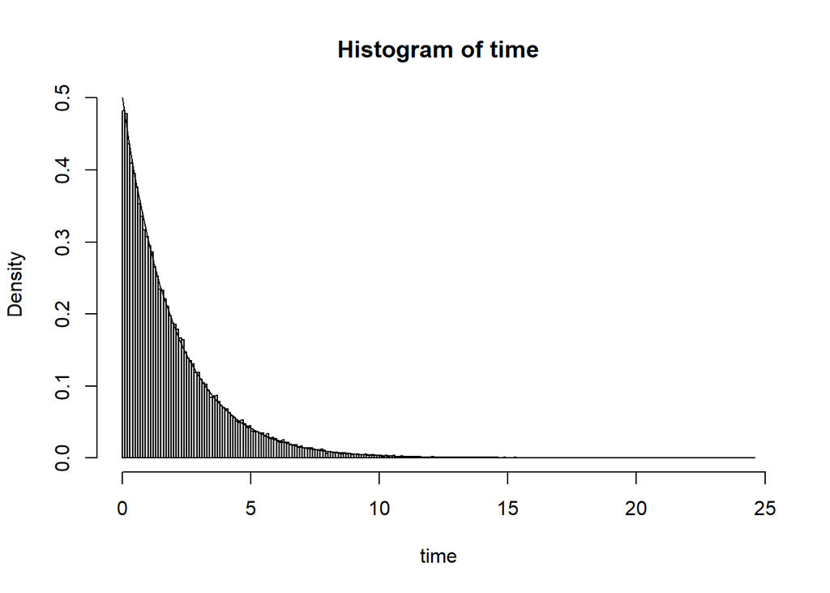

```r
inter=rexp(100000, 1)
arr=cumsum(inter)
service = rexp(100000,1.5)

output <- arr[1] + service[1]
for (i in 1:99999){
if (arr[i+1] < output[i]){output <- c(output, output[i] + service[i+1])}
if (arr[i+1] > output[i]){output <- c(output, arr[i+1] + service[i+1])}
output
}
time = output - arr
x = seq(0,max(time)+1, by=0.01)
b = seq(0,max(time)+1, by=0.1)
hist(time, prob=T, breaks=b)
curve(dexp(x,0.5), add=T)
```